# Sparkify Project Workspace

This workspace contains a tiny subset (128MB) of the full dataset available (12GB). Feel free to use this workspace to build your project, or to explore a smaller subset with Spark before deploying your cluster on the cloud. Instructions for setting up your Spark cluster is included in the last lesson of the Extracurricular Spark Course content.

You can follow the steps below to guide your data analysis and model building portion of this project.

# Project Overview

**Sparkify** is a fictional music streaming service platform created by Udacity just like Spotify and Pandora. Users can stream songs with either free or premium subscription (monthly flat rate is charged) using Sparkify, and they can upgrade, downgrade or cancel their service at anytime. All these user interactions with platform are logged as event data such as page visited, date and time, users details, sessions details, etc.

When it comes to machine learning on large dataset, **Spark MLlib (Machine Learning library)** is a popular choise for distributed computing, in-memory processing, scalability and ease of use. In Capstone Project, we will manipulate a smaller subset of users event dataset using Apache Spark to build a machine learning model for predicting churn rates in Sparkify plaform.

```python
# import libraries
from pyspark.sql import SparkSession, Window
from pyspark.sql.functions import *
from pyspark.sql.functions import desc
from pyspark.sql.functions import asc
from pyspark.sql.types import *
from pyspark.sql.types import StringType
from pyspark.sql.functions import sum as Fsum
from pyspark.sql.functions import max as Fmax

from pyspark.ml import Pipeline
from pyspark.ml.classification import LogisticRegression,  RandomForestClassifier, LinearSVC, GBTClassifier
from pyspark.ml.feature import StandardScaler, VectorAssembler, Normalizer, StringIndexer
from pyspark.ml.evaluation import MulticlassClassificationEvaluator
from pyspark.mllib.evaluation import MulticlassMetrics
from pyspark.ml.tuning import CrossValidator, ParamGridBuilder

import re
import time
import datetime
import numpy as np
import pandas as pd
import seaborn as sns
import matplotlib.pyplot as plt
%matplotlib inline
from statsmodels.stats.proportion import proportions_ztest
```

```python
# create a Spark session
spark = SparkSession.builder.appName("Sparkify Churn Prediction").getOrCreate()
```

# Load and Clean Dataset

In this workspace, the mini-dataset file is `mini_sparkify_event_data.json`. Load and clean the dataset, checking for invalid or missing data - for example, records without userids or sessionids.

```python
# create a function to load dataset in json format
def load_json_data(file_path):
    """
    PURPOSE: Load Spark dataset in JSON format
    INPUT:
        file_path (string) - path to json file
    OUTPUT:
        df (PySpark dataframe) - a dataframe populated with data read from json file
    """
    return spark.read.json(file_path)

user_log = load_json_data("mini_sparkify_event_data.json")
```

Let's examane the schema and dimension of the dataset.

```python
# Display the schema of dataframe
user_log.printSchema()
```

```
root
 |-- artist: string (nullable = true)
 |-- auth: string (nullable = true)
 |-- firstName: string (nullable = true)
 |-- gender: string (nullable = true)
 |-- itemInSession: long (nullable = true)
 |-- lastName: string (nullable = true)
 |-- length: double (nullable = true)
 |-- level: string (nullable = true)
 |-- location: string (nullable = true)
 |-- method: string (nullable = true)
 |-- page: string (nullable = true)
 |-- registration: long (nullable = true)
 |-- sessionId: long (nullable = true)
 |-- song: string (nullable = true)
 |-- status: long (nullable = true)
 |-- ts: long (nullable = true)
 |-- userAgent: string (nullable = true)
 |-- userId: string (nullable = true)
```

```python
# Get dimension of dataset - number of rows and columns
print(f"Count of records: {user_log.count()}, number of columns: {len(user_log.columns)}")
```

```
Count of records: 286500, number of columns: 18
```

Overall, there are 286500 rows of records in this small dataset with a total of 18 columns. All columns can be nullable and most columns are string data type like `userId`, `userAgent`, `location`, `gender`, etc. capturing user interaction details. Some are integer and floating-point data type such as `registration`, `time`, `length` which requires data transformation for analysis.

```python
# take a look at first 5 rows of records
user_log.take(5)
```

```
[Row(artist='Martha Tilston', auth='Logged In', firstName='Colin', gender='M', itemInSession=50, lastName='Freeman', length=277.89016, level='paid', location='Bakersfield, CA', method='PUT', page='NextSong', registration=1538173362000, sessionId=29, song='Rockpools', status=200, ts=1538352117000, us…
 Row(artist='Five Iron Frenzy', auth='Logged In', firstName='Micah', gender='M', itemInSession=79, lastName='Long', length=236.09424, level='free', location='Boston-Cambridge-Newton, MA-NH', method='PUT', page='NextSong', registration=1538331630000, sessionId=8, song='Canada', status=200, ts=1538352…
 Row(artist='Adam Lambert', auth='Logged In', firstName='Colin', gender='M', itemInSession=51, lastName='Freeman', length=282.8273, level='paid', location='Bakersfield, CA', method='PUT', page='NextSong', registration=1538173362000, sessionId=29, song='Time For Miracles', status=200, ts=153835239400…
 Row(artist='Enigma', auth='Logged In', firstName='Micah', gender='M', itemInSession=80, lastName='Long', length=262.71302, level='free', location='Boston-Cambridge-Newton, MA-NH', method='PUT', page='NextSong', registration=1538331630000, sessionId=8, song='Knocking On Forbidden Doors', status=200,…
 Row(artist='Daft Punk', auth='Logged In', firstName='Colin', gender='M', itemInSession=52, lastName='Freeman', length=223.60771, level='paid', location='Bakersfield, CA', method='PUT', page='NextSong', registration=1538173362000, sessionId=29, song='Harder Better Faster Stronger', status=200, ts=15…
```

```python
# generate descriptive statistics for userId
user_log.describe("userId").show()
```

```
+-------+------------------+
|summary|            userId|
+-------+------------------+
|  count|            286500|
|   mean| 59682.02278593872|
| stddev|109091.94999910535|
|    min|                  |
|    max|                99|
+-------+------------------+
```

# Drop Rows with Missing Values

First, let's examine the dataset to identify any column with missing values, especially userId and sessionId. We must clean up missing values like NaN and empty string for `userId` and `sessionId` if there is any as these 2 columns are related to play song records.

```python
# Check for missing value - NaN and '' for each column
def check_missing_value(df):
    """
    PURPOSE: Check for NaN and '' for every record
    INPUT:
        df (dataset) - a dataset with user event records
    OUTPUT:
        n/a
    """
    for col in df.columns:
        missing_count = df.filter(df[col].isNull() | (df[col] == "") | isnan(df[col])).count()
        if missing_count > 0:
            print(f"{col} = {missing_count}")

check_missing_value(user_log)
```

```
artist = 58392
firstName = 8346
gender = 8346
lastName = 8346
length = 58392
location = 8346
registration = 8346
song = 58392
userAgent = 8346
userId = 8346
```

```python
# drop drop NaN and '' (empty strings) for userId column
user_log_valid = user_log.filter(user_log['userId'].isNotNull() \
                                 & (user_log['userId'] != "") \
                                 & ~isnan(user_log['userId']))

user_log_valid.head()
```

```
Row(artist='Martha Tilston', auth='Logged In', firstName='Colin', gender='M', itemInSession=50, lastName='Freeman', length=277.89016, level='paid', location='Bakersfield, CA', method='PUT', page='NextSong', registration=1538173362000, sessionId=29, song='Rockpools', status=200, ts=1538352117000, use…
```

```python
# Re-examine if missing values are clean up
check_missing_value(user_log_valid)

# Count number of rows in dataset after cleaning
print(f"After cleaning, there are {user_log_valid.count()} rows of records.")
```

```
artist = 50046
length = 50046
song = 50046
After cleaning, there are 278154 rows of records.
```

There is a high number of records with NaNs in `artist`, `length` and `song` variable, we should not remove it as it represents other user interactions which are not related to playing songs like visiting Home page, adding friends, etc.

### Convert Timestamp from Epoch to Date Time

Now we have clean up missing values for userId and there isn't any NaN or empty string found in sessionId. Next, let's transform `ts` and `registration` into datetime format to improve readability by adding 2 new columns into dataset.

```python
# User Defined Function
# convert timestamp to date time from epoch time
convert_datetime = udf(lambda x: datetime.datetime.fromtimestamp(x / 1000.0).strftime("%Y-%m-%d %H:%M:%S"))
```

```python
# add new variable - datetime (a string representing date and time)
user_log_valid= user_log_valid.withColumn("datetime", convert_datetime(user_log_valid.ts))
```

```python
# add new variable - registration (a string representing date and time)
user_log_valid = user_log_valid.withColumn("registration_datetime", convert_datetime(user_log_valid.registration))
```

```python
# User Defined Function
# calculate days of service each user subscribed by substract timestamp and registration
calculate_duration = udf(lambda x,y: float((x-y) / (1000*60*60*24)))

# add new variable - days_of_subscription (an integer)
user_log_valid = user_log_valid.withColumn("days_of_subscription", calculate_duration(user_log_valid.ts, user_log_valid.registration))
user_log_valid = user_log_valid.withColumn("days_of_subscription", user_log_valid["days_of_subscription"].cast(IntegerType()))
```

### Extract Browser and Platform from UserAgent variable

We can identify the application (browser), operation system (platform), version and its vendor by extracting these data from `userAgent` variable and populate it into new variables - `browser` and `plaform`

```python
# Extract keyword from userAgent variable and map it to respective browser name
def get_browser_udf(user_agent):
    # Map the browser by keywords
    if "Firefox" in user_agent:
        return "Firefox"
    elif "Safari" in user_agent and "Chrome" in user_agent:
        return "Chrome"
    elif "Safari" in user_agent:
        return "Safari"
    elif "Trident" in user_agent:
        return "IE"
    else:
        return np.NaN

# Register the UDF with the correct return type
get_browser = udf(get_browser_udf, StringType())
```

```python
user_log_valid = user_log_valid.withColumn("browser", get_browser(user_log_valid.userAgent))
```

```python
# Define a UDF to extract and map the platform
def get_platform_udf (user_agent):
    # Map the browser by keywords
    if "compatible" in user_agent or "Windows" in user_agent:
        return "Windows"
    elif "iPad" in user_agent:
        return "iPad"
    elif "iPhone" in user_agent:
        return "iPhone"
    elif "X11" in user_agent:
        return "Linux"
    elif "Macintosh" in user_agent:
        return "Mac"
    else:
        return np.NaN

# Register the UDF with the correct return type
get_platform = udf(get_platform_udf, StringType())
```

```python
user_log_valid = user_log_valid.withColumn("platform", get_platform(user_log_valid.userAgent))
```

### Create Weekday variable (user interactions during weekday)

```python
# Create UDF to get weekday
get_weekday = udf(lambda x:datetime.datetime.fromtimestamp(x/1000).strftime('%w'))
```

```python
user_log_valid = user_log_valid.withColumn('weekday', get_weekday(user_log_valid.ts))
```

#### Get City and State from Top 10 Location

```python
user_log_valid = user_log_valid.withColumn('city', split(user_log_valid.location, ",").getItem(0))
```

```python
user_log_valid = user_log_valid.withColumn('state', split(user_log_valid.location, ",").getItem(1))
```

```python
user_log_valid.head()
```

```
Row(artist='Martha Tilston', auth='Logged In', firstName='Colin', gender='M', itemInSession=50, lastName='Freeman', length=277.89016, level='paid', location='Bakersfield, CA', method='PUT', page='NextSong', registration=1538173362000, sessionId=29, song='Rockpools', status=200, ts=1538352117000, use…
```

# Exploratory Data Analysis

When you're working with the full dataset, perform EDA by loading a small subset of the data and doing basic manipulations within Spark. In this workspace, you are already provided a small subset of data you can explore.

```python
# create a temporary view for sql queries
user_log_valid.createOrReplaceTempView("log_table")
```

First, we explore the gender distribution in this dataset. How many female and male users do we have in this dataset?

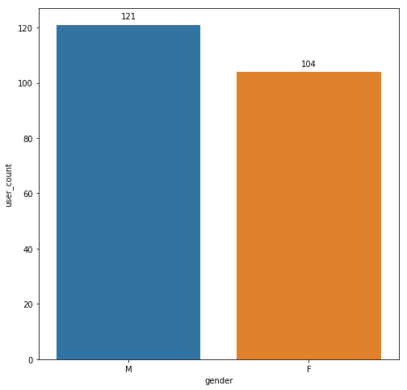

```python
gender_count = spark.sql("SELECT gender, COUNT(DISTINCT userId) as user_count \
                            FROM log_table \
                            GROUP BY gender \
                            ORDER BY user_count DESC")

# Set the figure size
plt.figure(figsize=(8,8))

# Create a bar plot
ax = sns.barplot(x='gender', y='user_count', data=gender_count.toPandas())

# Add data labels to each bar
for p in ax.patches:
    ax.annotate(f'{p.get_height():.0f}', (p.get_x() + p.get_width() / 2., p.get_height()),
                ha='center', va='center', xytext=(0, 10), textcoords='offset points')

plt.show()
```

Then, let's find out how many free users and paid users in this dataset.

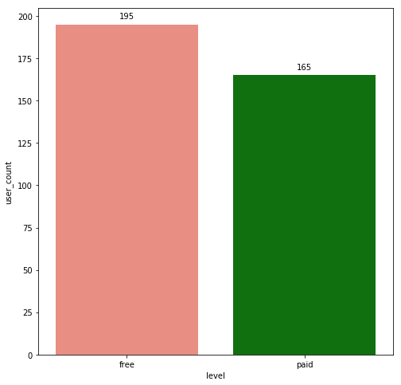

```python
user_count = spark.sql("SELECT level, COUNT(DISTINCT userId) as user_count \
                            FROM log_table \
                            GROUP BY level \
                            ORDER BY user_count DESC")

# Set the figure size
plt.figure(figsize=(8,8))

# Specify the bar color (e.g., 'skyblue' and 'salmon')
bar_colors = ['salmon', 'green']

# Create a bar plot
ax = sns.barplot(x='level', y='user_count', data=user_count.toPandas(), palette=bar_colors)

# Add data labels to each bar
for p in ax.patches:
    ax.annotate(f'{p.get_height():.0f}', (p.get_x() + p.get_width() / 2., p.get_height()),
                ha='center', va='center', xytext=(0, 10), textcoords='offset points')

plt.show()
```

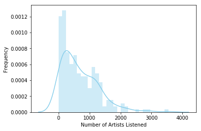

```python
artist_count = spark.sql("SELECT userId, COUNT(DISTINCT artist) AS num_artists\
                            FROM log_table \
                            GROUP BY userId \
                            ORDER BY num_artists DESC").toPandas()

artist_count = artist_count.dropna()

# Create a bar plot
sns.distplot(artist_count.num_artists, bins=30, color='skyblue', kde=True)
plt.xlabel('Number of Artists Listened')
plt.ylabel('Frequency')
plt.show()
```

### Define Churn

Once you've done some preliminary analysis, create a column `Churn` to use as the label for your model. I suggest using the `Cancellation Confirmation` events to define your churn, which happen for both paid and free users. As a bonus task, you can also look into the `Downgrade` events.

How do we know if there is any user cancelled the service?

```python
spark.sql("SELECT auth, COUNT(DISTINCT userId) as user_count\
            FROM log_table \
            GROUP BY auth").show()
```

```
+---------+----------+
|     auth|user_count|
+---------+----------+
|Cancelled|        52|
|Logged In|       225|
+---------+----------+
```

There are 52 users cancelled the service. Were all of them visited `Cancellation Confirmation` page as well?

```python
spark.sql("SELECT page, COUNT(DISTINCT userId) as user_count \
            FROM log_table \
            WHERE page == 'Cancellation Confirmation' \
            GROUP BY page").show()
```

```
+--------------------+----------+
|                page|user_count|
+--------------------+----------+
|Cancellation Conf...|        52|
+--------------------+----------+
```

Based on the query result, the number of users has cancelled the service is tally with the number of users visited `Cancellation Confirmation` page. How is the distribution of days of subscription for active and churn users?

```
Text(0.5,0,'Days of Subscription')
```

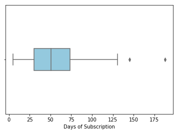

```python
user_cancelled = spark.sql("SELECT userId, auth, datetime, days_of_subscription \
                            FROM log_table \
                            WHERE page == 'Cancellation Confirmation' \
                            ORDER BY datetime DESC").toPandas()

# Create a bar plot
sns.boxplot(user_cancelled.days_of_subscription, color='skyblue', width=0.2)
plt.xlabel('Days of Subscription')
```

# User Churn

```python
flag_churn_event = udf(lambda x:1 if x == "Cancellation Confirmation" else 0, IntegerType())
```

```python
user_log_valid = user_log_valid.withColumn("churn_event", flag_churn_event("page"))
```

# Users Downgrade Their Accounts

```python
flag_downgrade_event = udf(lambda x:1 if x == "Submit Downgrade" else 0, IntegerType())
```

```python
user_log_valid = user_log_valid.withColumn("downgraded", flag_downgrade_event("page"))
```

```python
user_log_valid.head()
```

```
Row(artist='Martha Tilston', auth='Logged In', firstName='Colin', gender='M', itemInSession=50, lastName='Freeman', length=277.89016, level='paid', location='Bakersfield, CA', method='PUT', page='NextSong', registration=1538173362000, sessionId=29, song='Rockpools', status=200, ts=1538352117000, use…
```

```python
windowval = Window.partitionBy("userId").orderBy(desc("ts")).rangeBetween(Window.unboundedPreceding, 0)
```

```python
user_log_churn = user_log_valid.withColumn("churn", Fmax("churn_event").over(windowval))
```

```python
user_log_churn = user_log_churn.withColumn("phase", Fsum("downgraded").over(windowval))
```

```python
user_log_churn.head()
```

```
Row(artist=None, auth='Logged In', firstName='Darianna', gender='F', itemInSession=34, lastName='Carpenter', length=None, level='free', location='Bridgeport-Stamford-Norwalk, CT', method='PUT', page='Logout', registration=1538016340000, sessionId=187, song=None, status=307, ts=1542823952000, userAge…
```

### Explore Data

Once you've defined churn, perform some exploratory data analysis to observe the behavior for users who stayed vs users who churned. You can start by exploring aggregates on these two groups of users, observing how much of a specific action they experienced per a certain time unit or number of songs played.

```python
# Update temporary view
user_log_churn.createOrReplaceTempView("churn_log_table")
```

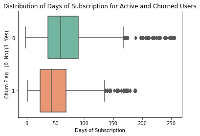

```python
# Get subscription period for active & churn users
subscription_duration = spark.sql("SELECT userId, churn, days_of_subscription \
                                FROM churn_log_table \
                                ORDER BY days_of_subscription DESC").toPandas()

sns.boxplot(x='days_of_subscription', y='churn', data=subscription_duration, palette='Set2', orient='h')
plt.xlabel('Days of Subscription')
plt.ylabel('Churn Flag - (0: No) (1: Yes)')
plt.title('Distribution of Days of Subscription for Active and Churned Users')
plt.show()
```

```python
# Get distribution of active & churn users by phase
level_count = spark.sql("SELECT churn, phase, COUNT(DISTINCT userId) AS no_of_users \
            FROM churn_log_table \
            GROUP BY churn , phase \
            ORDER BY churn ASC, phase ASC").show()
```

```
+-----+-----+-----------+
|churn|phase|no_of_users|
+-----+-----+-----------+
|    0|    0|        173|
|    0|    1|         40|
|    0|    2|         12|
|    0|    3|          2|
|    1|    0|         52|
|    1|    1|          9|
+-----+-----+-----------+
```

We can use statistical proportions test to evaluate our null hypotheses

#### 1. Females and males are equally likely to cancel service.

```python
gender_count = spark.sql("SELECT churn, gender, COUNT(DISTINCT userId) AS user_count \
                            FROM churn_log_table \
                            GROUP BY churn, gender \
                            ORDER BY churn, gender DESC").toPandas()

unstacked_gender = gender_count.pivot(index='churn', columns='gender', values='user_count').fillna(0)
```

```python
# Map index values in unstacked_gender to more descriptive labels
map_dict_churn = {0:'Active Users',1:'Churned Users'}
unstacked_gender.index = unstacked_gender.index.map(map_dict_churn)
```

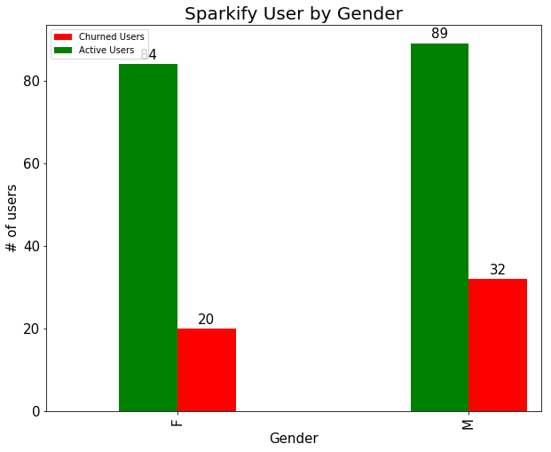

```python
# Set plot labels and title
plt.title('Sparkify User by Gender', fontsize=20)
ax = unstacked_gender.iloc[1].plot(kind='bar', color='r', position=0, width=0.2, figsize=(10, 8), legend=True, fontsize=15)
ax = unstacked_gender.iloc[0].plot(kind='bar', color='g', position=1, width=0.2, legend=True, fontsize=15)
ax.set_xlabel("Gender", fontsize=15)
ax.set_ylabel("# of users", fontsize=15)

# Add data labels to the bars
for p in ax.patches:
    ax.annotate(str(p.get_height()), (p.get_x() + p.get_width() / 2., p.get_height()),
                ha='center', va='center', xytext=(0, 10), textcoords='offset points', fontsize=15)

# Show the plot
plt.show()
```

```python
user_log_churn.dropDuplicates(['userId', 'gender']).groupby(['churn', 'gender']).count().sort('churn').show()
```

```
+-----+------+-----+
|churn|gender|count|
+-----+------+-----+
|    0|     F|   84|
|    0|     M|   89|
|    1|     M|   32|
|    1|     F|   20|
+-----+------+-----+
```

```python
stat, pval = proportions_ztest([32,20],[121,104],alternative='two-sided')
print(f"Test statistic for z-test = {stat}")
print(f"p-value for z-test = {pval}")
```

```
Test statistic for z-test = 1.2800974409737422
p-value for z-test = 0.20051086855629463
```

As the p-value is greater than 0.2, it is suggested that we do not have sufficient evidence to reject our null hypothesis that gender has no impact on churn probability.

#### 2. Are users listening to songs longer time are less likely to cancel service?

```python
spark.sql("SELECT churn, AVG(length), MAX(length) as max_length, MIN(length) as min_length\
            FROM churn_log_table \
            GROUP BY churn \
            ORDER BY churn DESC").show()
```

```
+-----+------------------+----------+----------+
|churn|       avg(length)|max_length|min_length|
+-----+------------------+----------+----------+
|    1| 248.6327956440622|3024.66567|   4.04853|
|    0|249.20913538880808|3024.66567|   0.78322|
+-----+------------------+----------+----------+
```

The average length of time a user listens to songs is almost same for both group of users. Hence, we can conclude that there is no impact of `length` on the `churn` variable.

#### 3. Free and paid users are equally likely to cancel service

```python
spark.sql("SELECT churn, level, COUNT(DISTINCT userId) as user_count \
            FROM churn_log_table \
            GROUP BY churn, level \
            ORDER BY churn, level DESC").show()
```

```
+-----+-----+----------+
|churn|level|user_count|
+-----+-----+----------+
|    0| paid|       129|
|    0| free|       149|
|    1| paid|        36|
|    1| free|        46|
+-----+-----+----------+
```

```python
stat, pval = proportions_ztest([46,36],[(46+149), (36+129)],alternative='two-sided')
print(f"Test statistic for z-test = {stat}")
print(f"p-value for z-test = {pval}")
```

```
Test statistic for z-test = 0.39933511788567505
p-value for z-test = 0.689646294328303
```

We do not have sufficient evidence to reject the null hypothesis that free and paid users are equally likely to cancel the service due to large p-value (0.68).

#### 4. What are the pages users visited?

```python
# Extract count of events by page for churn user into a dataframe
churn_page_count = spark.sql("SELECT page, COUNT(page) AS page_count \
                        FROM churn_log_table \
                        WHERE churn == 1 \
                        GROUP BY page \
                        ORDER BY page DESC").toPandas()
```

```python
churn_page_count = churn_page_count.rename(columns={"page_count": "churn users"})
```

```python
churn_page_count = churn_page_count.set_index('page')
```

```python
# Extract count of events by page for active user into a dataframe
active_page_count = spark.sql("SELECT page, COUNT(page) AS page_count \
                        FROM churn_log_table \
                        WHERE churn == 0 \
                        GROUP BY page \
                        ORDER BY page DESC").toPandas()
```

```python
active_page_count = active_page_count.rename(columns={"page_count": "active users"})
```

```python
active_page_count = active_page_count.set_index('page')
```

```python
# Combine number of events by page for active users and churn users into common dataframe for visualization purpose
page_count = pd.concat([churn_page_count, active_page_count], axis=1, join='inner')
```

As the total event count of `NextSong` page is too significant, let's exclude it in next data visualization to improve readability.

```python
page_count = page_count.drop(index='NextSong').sort_values(by=['churn users', 'active users', ], ascending=True)
```

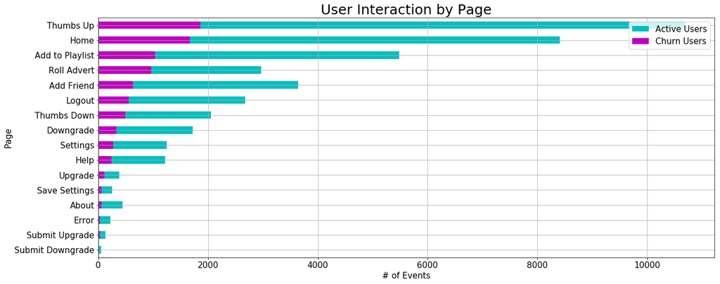

```python
# Set plot labels and title
plt.title('User Interaction by Page', fontsize=25)
ax = page_count['active users'].plot(kind='barh',figsize=(20,8), fontsize=15, color='c')
ax = page_count['churn users'].plot(kind='barh', figsize=(20,8), fontsize=15, color='m')
ax.set_ylabel("Page", fontsize=15)
ax.set_xlabel("# of Events", fontsize=15)

# Display the legend with explicit labels
plt.legend(["Active Users", "Churn Users"], fontsize=15, loc='upper right')

# Show the plot
plt.grid(True)
plt.show()
```

By excluding NexSong (most submitted page), apparently both group of users visited Thumbs Up, Home, Add to Playlist, Add Friend and Roll Advert page. For churn users, obviously Thumbs Up, Home and Add to Playlist seems giving an impact on respective page count.

#### 5. What are the browsers commonly used?

```python
browser_count = spark.sql("SELECT churn, browser, COUNT(DISTINCT userId) AS user_count \
                            FROM churn_log_table \
                            GROUP BY churn, browser \
                            ORDER BY churn, browser DESC").toPandas()

unstacked_browser = browser_count.pivot(index='churn', columns='browser', values='user_count').fillna(0)
```

```python
# Map index values in unstacked_browser to more descriptive labels
map_dict_churn = {0:'Active Users',1:'Churned Users'}
unstacked_browser.index = unstacked_browser.index.map(map_dict_churn)
```

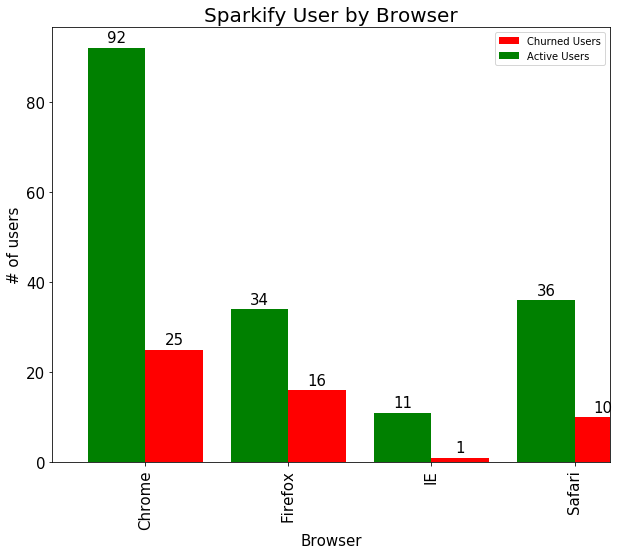

```python
# Set plot labels and title
plt.title('Sparkify User by Browser', fontsize=20)
ax = unstacked_browser.iloc[1].plot(kind='bar', color='r', position=0, width=0.4, figsize=(10, 8), legend=True, fontsize=15)
ax = unstacked_browser.iloc[0].plot(kind='bar', color='g', position=1, width=0.4, legend=True, fontsize=15)
ax.set_xlabel("Browser", fontsize=15)
ax.set_ylabel("# of users", fontsize=15)

# Add data labels to the bars
for p in ax.patches:
    ax.annotate(str(p.get_height()), (p.get_x() + p.get_width() / 2., p.get_height()),
                ha='center', va='center', xytext=(0, 10), textcoords='offset points', fontsize=15)

# Show the plot
plt.show()
```

Both group of users use Chrome, Firefox and Safari while listening songs. Apparently IE is not really favorable compared to other browsers.

#### 6. Are users using mobile or desktop/laptop to listen to songs?

```python
platform_count = spark.sql("SELECT churn, platform, COUNT(DISTINCT userId) AS user_count \
                            FROM churn_log_table \
                            GROUP BY churn, platform \
                            ORDER BY churn, platform DESC").toPandas()

unstacked_platform = platform_count.pivot(index='churn', columns='platform', values='user_count').fillna(0)

# Map index values in unstacked_browser to more descriptive labels
map_dict_churn = {0:'Active Users',1:'Churned Users'}
unstacked_platform.index = unstacked_platform.index.map(map_dict_churn)
```

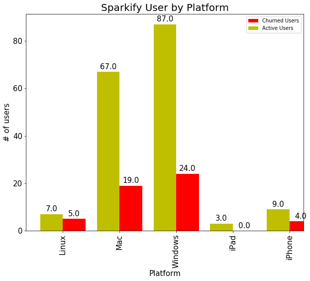

```python
# Set plot labels and title
plt.title('Sparkify User by Platform', fontsize=20)
ax = unstacked_platform.iloc[1].plot(kind='bar', color='r', position=0, width=0.4, figsize=(10, 8), legend=True, fontsize=15)
ax = unstacked_platform.iloc[0].plot(kind='bar', color='y', position=1, width=0.4, legend=True, fontsize=15)
ax.set_xlabel("Platform", fontsize=15)
ax.set_ylabel("# of users", fontsize=15)

# Add data labels to the bars
for p in ax.patches:
    ax.annotate(str(p.get_height()), (p.get_x() + p.get_width() / 2., p.get_height()),
                ha='center', va='center', xytext=(0, 10), textcoords='offset points', fontsize=15)

# Show the plot
plt.show()
```

Most users are using desktop or laptop computers to operate Sparkify. The number of users using mobile devices and tablets is quite low.

#### 7. How is the distribution of churn and active users in weekday?

```python
weekday_churn = spark.sql("SELECT weekday, COUNT(*) AS churn_user \
                         FROM churn_log_table \
                         WHERE churn == 1 \
                         GROUP BY weekday \
                         ORDER BY CAST(weekday as INT) ASC").toPandas()
```

```python
weekday_active = spark.sql("SELECT weekday, COUNT(*) AS active_user \
                         FROM churn_log_table \
                         WHERE churn == 0 \
                         GROUP BY weekday \
                         ORDER BY CAST(weekday as INT) ASC").toPandas()
```

```python
weekday_churn = weekday_churn.set_index('weekday')
weekday_active = weekday_active.set_index('weekday')
weekday_count = pd.concat([weekday_churn, weekday_active], axis=1, join='outer')
```

```python
# Weekday as a decimal number, where 0 is Sunday and 6 is Saturday.
map_dict = {'0':'Sunday','1':'Monday','2':'Tuesday','3':'Wednesday','4':'Thursday','5':'Friday','6':'Saturday'}
weekday_count.index = weekday_count.index.map(map_dict)
```

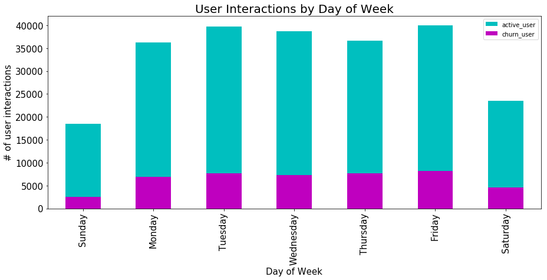

```python
plt.title('User Interactions by Day of Week', fontsize=20)

ax = weekday_count['active_user'].plot(kind='bar', color ='c', figsize=(15, 6), legend=True, fontsize=15)
ax = weekday_count['churn_user'].plot(kind='bar', color ='m', legend=True, fontsize=15)
ax.set_xlabel("Day of Week", fontsize=15)
ax.set_ylabel("# of user interactions", fontsize=15)
plt.show()
```

#### 8. Distribution of Sparkify User Churn Rate by State

```python
state_churn = spark.sql("SELECT state, COUNT(DISTINCT userId) AS churn_users \
                        FROM churn_log_table \
                        WHERE churn == 1 \
                        GROUP BY state \
                        ORDER BY churn_users DESC").toPandas()
```

```python
state_active = spark.sql("SELECT state, COUNT(DISTINCT userId) AS active_users \
                        FROM churn_log_table \
                        WHERE churn == 0 \
                        GROUP BY state \
                        ORDER BY active_users DESC").toPandas()
```

```python
state_churn = state_churn.set_index('state')
state_active = state_active.set_index('state')
#location_count = pd.concat([state_churn.groupby('state').sum(), state_active.groupby('state').sum()], \
                           #axis=1, join='outer', sort=True)
location_count = pd.concat([state_churn, state_active], axis=1, join='outer', sort=True)
location_count = location_count.sort_values(by=['churn_users', 'active_users', ], ascending=False)
```

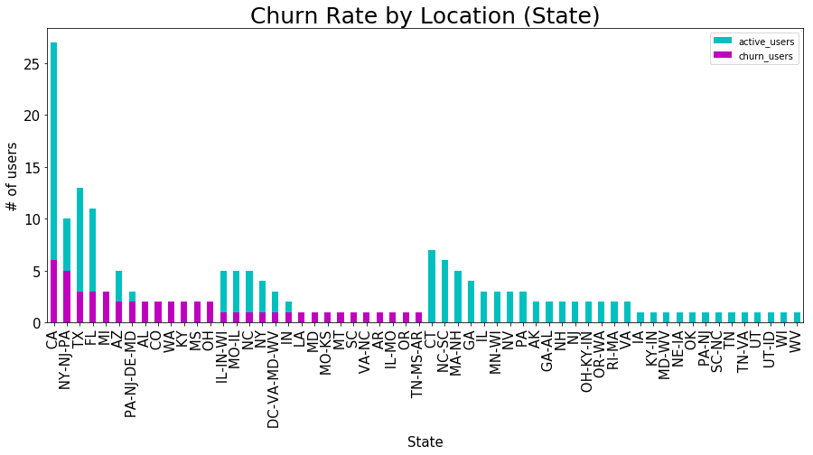

```python
plt.title('Churn Rate by Location (State)', fontsize=25)

ax = location_count['active_users'].plot(kind='bar', color ='c', figsize=(15, 6), legend=True, fontsize=15)
ax = location_count['churn_users'].plot(kind='bar', color ='m', legend=True, fontsize=15)
ax.set_xlabel("State", fontsize=15)
ax.set_ylabel("# of users", fontsize=15)

plt.show()
```

The graph shows most Sparkify users are located at the states with large population as below:

- **CA** (California) Population: 38,915,693
- **TX** (Texas) Population: 30,500,280
- **NY-NJ-PA** (New York-New Jersey-Pennsylavia) Total Population: 41,684,204
- **FL** (Florida) Population: 22,661,577

Refer to https://worldpopulationreview.com/states for population information.

#### Distribution of Number of Artists Played

Let's find out number of artists played by users.

```python
artist_count = spark.sql("SELECT churn, COUNT(DISTINCT artist) AS artist_count \
                        FROM churn_log_table \
                        GROUP BY churn \
                        ORDER BY artist_count DESC").toPandas()
```

```python
# Map index values in unstacked_browser to more descriptive labels
map_dict_churn = {0:'Active Users',1:'Churned Users'}
artist_count.index = artist_count.index.map(map_dict_churn)
```

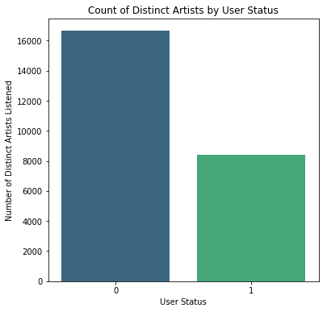

```python
plt.figure(figsize=(6, 6))
sns.barplot(x='churn', y='artist_count', data=artist_count, palette='viridis')
plt.xlabel('User Status')
plt.ylabel('Number of Distinct Artists Listened')
plt.title('Count of Distinct Artists by User Status')
plt.show()
```

# Feature Engineering

Once you've familiarized yourself with the data, build out the features you find promising to train your model on. To work with the full dataset, you can follow the following steps.

- Write a script to extract the necessary features from the smaller subset of data
- Ensure that your script is scalable, using the best practices discussed in Lesson 3
- Try your script on the full data set, debugging your script if necessary

If you are working in the classroom workspace, you can just extract features based on the small subset of data contained here. Be sure to transfer over this work to the larger dataset when you work on your Spark cluster.

```python
user_log_churn.createOrReplaceTempView("churn_log_table")
```

I have selected the following features for the model to predict potential churn users.

```python
features = spark.sql("SELECT userId, \
                     MAX(churn) AS label, \
                     COUNT(CASE WHEN page = 'NextSong' THEN 1 ELSE null END) AS song_count, \
                     COUNT(CASE WHEN page = 'Add Friend' THEN 1 ELSE null END) AS friend_count, \
                     COUNT(CASE WHEN page = 'Add to Playlist' THEN 1 ELSE null END) AS playlist_count, \
                     COUNT(CASE WHEN page = 'Thumbs Up' THEN 1 ELSE null END) AS thumbs_up_count, \
                     COUNT(CASE WHEN page = 'Thumbs Down' THEN 1 ELSE null END) AS thumbs_down_count, \
                     COUNT(CASE WHEN page = 'Downgrade' THEN 1 ELSE null END) AS downgrade, \
                     COUNT(CASE WHEN page = 'Roll Advert' THEN 1 ELSE null END) AS roll_advert, \
                     COUNT(CASE WHEN page = 'Submit Downgrade' THEN 1 ELSE null END) AS submit_downgrade, \
                     COUNT(CASE WHEN page = 'Error' THEN 1 ELSE null END) AS error_count, \
                     INT(CASE WHEN LAST(level) = 'free' THEN True ElSE False END) AS last_level_free, \
                     INT(CASE WHEN LAST(level) = 'paid' THEN True ElSE False END) AS last_level_paid, \
                     INT(CASE WHEN FIRST(gender) = 'F' THEN True ElSE False END) AS female_count, \
                     INT(CASE WHEN FIRST(gender) = 'M' THEN True ElSE False END) AS male_count, \
                     AVG(weekday) AS weekday, \
                     SUM(downgraded) AS phase, \
                     COUNT(DISTINCT artist) AS artist_count, \
                     COUNT(CASE WHEN platform = 'Windows' THEN 1 ELSE null END) AS windows_count, \
                     COUNT(CASE WHEN platform = 'Mac' THEN 1 ELSE null END) AS mac_count, \
                     COUNT(CASE WHEN platform = 'iPhone' THEN 1 ELSE null END) AS mobile_count, \
                     MAX(days_of_subscription) AS days_subscription, \
                     COUNT(DISTINCT sessionId) AS session_count, \
                     SUM(length/(60*60)) AS usage_hours \
                     FROM churn_log_table \
                     GROUP BY userId")
```

```python
features.createOrReplaceTempView("feature_engineering")
```

```python
df_features = features.toPandas()
```

```python
# Check any column with null values in the dataframe to
print(df_features.columns[df_features.isnull().any()])
```

```
Index([], dtype='object')
```

```python
df_features.describe()
```

|  | label | song_count | friend_count | playlist_count | thumbs_up_count | thumbs_down_count | downgrade | roll_advert | submit_downgrade | error_count | ... | male_count | weekday | phase | artist_count | windows_count | mac_count | mobile_count | days_subscription | session_count | usage_hours |
| --- | --- | --- | --- | --- | --- | --- | --- | --- | --- | --- | --- | --- | --- | --- | --- | --- | --- | --- | --- | --- | --- |
| count | 225.000000 | 225.000000 | 225.000000 | 225.000000 | 225.000000 | 225.000000 | 225.000000 | 225.000000 | 225.000000 | 225.000000 | ... | 225.000000 | 225.000000 | 225.000000 | 225.000000 | 225.000000 | 225.000000 | 225.000000 | 225.000000 | 225.000000 | 225.000000 |
| mean | 0.231111 | 1013.813333 | 19.008889 | 29.004444 | 55.782222 | 11.315556 | 9.133333 | 17.480000 | 0.280000 | 1.120000 | ... | 0.537778 | 3.166313 | 0.280000 | 696.377778 | 639.426667 | 456.662222 | 49.742222 | 79.364444 | 14.115556 | 70.155089 |
| std | 0.422483 | 1104.960779 | 20.581717 | 32.716654 | 65.477925 | 13.077481 | 11.734412 | 21.550207 | 0.587671 | 1.472607 | ... | 0.499682 | 0.902470 | 0.587671 | 603.951870 | 1185.941442 | 926.424849 | 293.344926 | 37.646625 | 14.646885 | 76.499001 |
| min | 0.000000 | 3.000000 | 0.000000 | 0.000000 | 0.000000 | 0.000000 | 0.000000 | 0.000000 | 0.000000 | 0.000000 | ... | 0.000000 | 0.407895 | 0.000000 | 3.000000 | 0.000000 | 0.000000 | 0.000000 | 0.000000 | 1.000000 | 0.192130 |
| 25% | 0.000000 | 230.000000 | 5.000000 | 6.000000 | 11.000000 | 2.000000 | 0.000000 | 3.000000 | 0.000000 | 0.000000 | ... | 0.000000 | 2.603032 | 0.000000 | 207.000000 | 0.000000 | 0.000000 | 0.000000 | 59.000000 | 6.000000 | 16.009215 |
| 50% | 0.000000 | 675.000000 | 14.000000 | 17.000000 | 35.000000 | 7.000000 | 5.000000 | 11.000000 | 0.000000 | 1.000000 | ... | 1.000000 | 3.132246 | 0.000000 | 555.000000 | 0.000000 | 0.000000 | 0.000000 | 73.000000 | 10.000000 | 46.692719 |
| 75% | 0.000000 | 1571.000000 | 27.000000 | 44.000000 | 81.000000 | 16.000000 | 13.000000 | 22.000000 | 0.000000 | 2.000000 | ... | 1.000000 | 3.756306 | 0.000000 | 1098.000000 | 872.000000 | 379.000000 | 0.000000 | 100.000000 | 18.000000 | 109.000415 |
| max | 1.000000 | 8002.000000 | 143.000000 | 240.000000 | 437.000000 | 75.000000 | 73.000000 | 128.000000 | 3.000000 | 7.000000 | ... | 1.000000 | 6.000000 | 3.000000 | 3544.000000 | 9632.000000 | 4825.000000 | 3051.000000 | 256.000000 | 107.000000 | 553.098588 |

8 rows × 23 columns

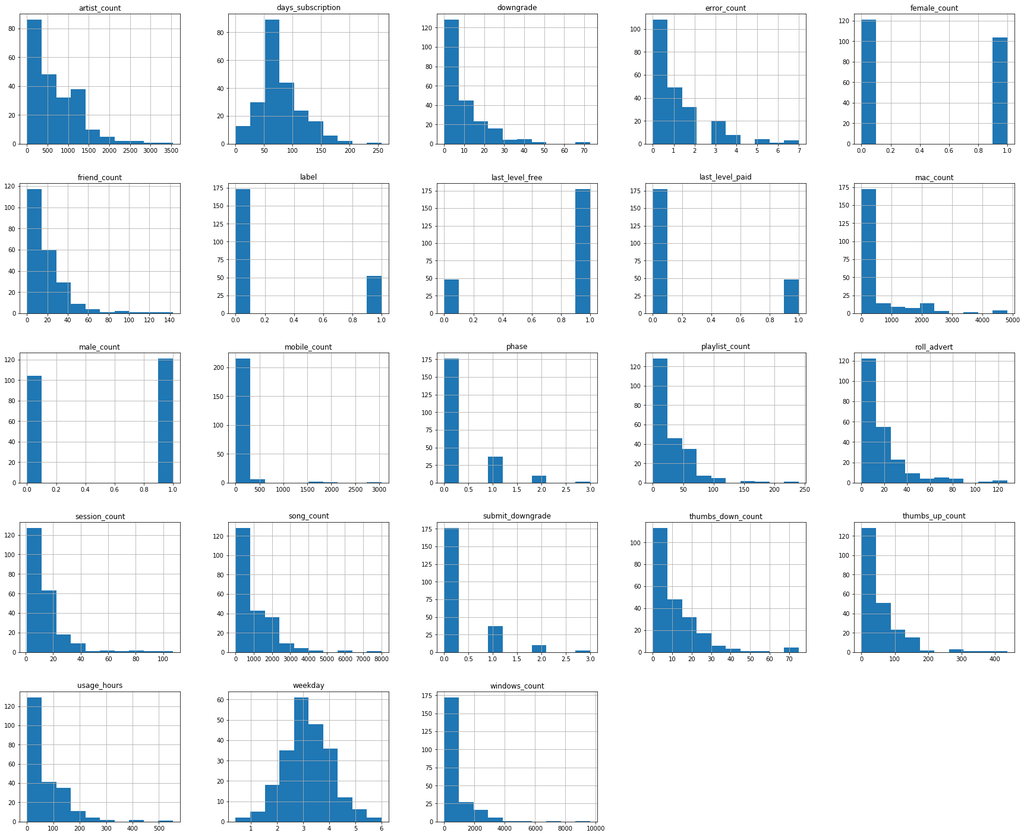

```python
fig = plt.figure(figsize=(30,25))
ax = fig.gca()
h = df_features.hist(ax=ax)
```

# Modeling

Split the full dataset into train, test, and validation sets. Test out several of the machine learning methods you learned. Evaluate the accuracy of the various models, tuning parameters as necessary. Determine your winning model based on test accuracy and report results on the validation set. Since the churned users are a fairly small subset, I suggest using F1 score as the metric to optimize.

### Step 1: Split the data into train and test subsets

```python
train, test = features.randomSplit([0.8, 0.2], seed=42)
```

### Step 2: Transform features in pipeline and build model

```python
def get_col_names(features):
    """
    PURPOSE: Get the names of numeric columns from the given Spark DataFrame features.
    INPUT
        - features: a Spark DataFrame with a schema attribute.
    OUTPUT
        - num_cols: a list of column names representing numeric columns.
    """
    num_cols = []

    for field in features.schema.fields:
        # Assuming that StringType() is used to identify non-numeric columns
        if field.dataType != StringType():
            num_cols.append(field.name)

    if 'label' in num_cols:
        num_cols.remove('label')

    return num_cols
```

```python
def build_model (classifier, param):
    """
    PURPOSE: Build and configure a machine learning model pipeline with cross-validation
    INPUT
        classifier - the machine learning classifier to be used in the pipeline.
        paramgrid - the parameter grid for hyperparameter tuning during cross-validation.
        features - the features to be used in the model, assumed to be defined elsewhere.
    OUTPUT
        model - the configured CrossValidator model
    """
    # Define a VectorAssembler to combine input features into a single vector column
    assembler = VectorAssembler(inputCols = get_col_names(features), outputCol = 'input_features')

    # Define a Normalizer to scale the input features
    scaler = Normalizer(inputCol="input_features", outputCol="scaled_features")

    # Create a Pipeline with the specified stages: VectorAssembler, Normalizer, and the classifier
    pipeline = Pipeline(stages=[assembler, scaler, classifier])

    # Create a CrossValidator with the pipeline, parameter grid, evaluator, and number of folds
    model = CrossValidator(
        estimator=pipeline,
        estimatorParamMaps=param,
        evaluator=MulticlassClassificationEvaluator(labelCol='label', metricName='f1'),
        numFolds=3
    )

    return model
```

### Step 3: Train Model

```python
def train_model(classifier_name, model):

    """
    PURPOSE: Train a machine learning model on a training dataset, measure the time taken for model fitting,
             and print relevant information.
    INPUT
        classifier_name (string) - the name of classifier
        model - the machine learning model to be trained
    OUTPUT
        fit_model - trained machine learning model
    """

    # Record the start time for measuring the duration of model fitting
    start = time.time()

    # Fit the provided model using the training dataset
    fit_model = model.fit(train)

    # Record the end time and calculate the duration of model fitting
    end = time.time()
    print(f"{classifier_name} model fitting took {end-start} seconds")
    print(f"AvgMetrics: {fit_model.avgMetrics}")

    # Return the trained model
    return fit_model
```

## Metrics Used for Model Performance Evaluation

### F1 Score

It is a metric commonly used in machine learning model to evaluate the performance of a model. It is particularly useful when dealing with imbalanced datasets where one class significantly outnumbers the other. In this project, we have high number of active users vs churned users with uneven distribution of gender, location, and interactions with platform. The F1 score combines precision and recall into a single metric, providing a balance between these two important aspects of a classification model's performance.

**Precision** - Number of True Positives / Number of True Positives + False Positives

*Precision tells us how many of the positive predictions made by the model are actually correct. In other words, it measures the accuracy of the model when it predicts something as positive. A high precision means that the model is making fewer false positive errors.*

**Recall** - Number of True Positives / Number of True Positives + False Negatives

*Recall tells us how many of the actual positive instances in the data were correctly predicted as positive by the model. It measures the model's ability to find all the positive instances. A high recall means that the model is making fewer false negative errors.*

### Accuracy

The Accuracy is commonly used to measure the overall correctness of a model's predictions.

**Accuracy** = Number of Correct Predictions / Total number of Predictions

For binary classification, accuracy can also be calculated in terms of positives and negatives as follows:

Accuracy = ( TP + TN ) / ( TP + TN + FP + FN )

Where TP = True Positives, TN = True Negatives, FP = False Positives, and FN = False Negatives

```python
def get_model_metrics (train_model, classifier_name):
    """
    PURPOSE: Calculate and print basic classification model metrics
    INPUT
        train_model - the trained machine learning model
        classifier_name - the name of classifier
    OUTPUT
        none
    """
    true_positive = (train_model.filter(train_model.label == train_model.prediction).count())
    total_no_predictions  = (train_model.count())

    print(f"{classifier_name} Model - Number of Correct Predictions: {true_positive}")
    print(f"{classifier_name} Model - Total Number of Predictions: {total_no_predictions}")
    print(f"{classifier_name} Model - Accuracy: {true_positive / total_no_predictions}")
```

### Step 5: Make Predictions

1. Make predictions on the test set
2. Evaluate the model using metrics like Precision, Recall and Accuracy.
3. Retrieve F1 score

```python
def predict_data (fit_model, classifier_name):
    """
    PURPOSE: Make predictions using a trained classifier, evaluate performance on the model on test dataset,
             then compute and print f1 score for specified classifier.
    INPUT
        classifier (string) - the name of classifier
        fit_model - trained machine learning model
    OUTPUT
        none
    """

    # Transform the test data using the trained model
    pred = fit_model.transform(test)

    # Display model metrics based on predictions
    get_model_metrics(pred, classifier_name)

    # Create a MulticlassClassificationEvaluator to evaluate the F1 score
    evaluator = MulticlassClassificationEvaluator(predictionCol="prediction", labelCol="label")

    # Evaluate and retrieve the F1 score
    f1_score = evaluator.evaluate(pred, {evaluator.metricName:"f1"})
    print("{} f1: {}".format(classifier_name, f1_score))
```

## Logistic Regression (LR)

Logistic Regression algorithm is widely used for binary classificiation task where target variable has two classes (e.g., yes/no, positive/negative). In this case, we want to predict user stay or churn. Hence, we started first prediction using Logistic Regression model.

```python
# Logistic Regression
lr = LogisticRegression(featuresCol="scaled_features", labelCol="label")
lr_param = ParamGridBuilder().build()
lr_model = build_model(lr, lr_param)
lr_fit_model = train_model("Logistic Regression", lr_model)
```

```
Logistic Regression model fitting took 1084.8365597724915 seconds
AvgMetrics: [0.73720874732512]
```

```python
# Make prediction using a trained Logistic Regression model
predict_data(lr_fit_model, "Logistic Regression")
```

```
Logistic Regression Model - Number of Correct Predictions: 28
Logistic Regression Model - Total Number of Predictions: 34
Logistic Regression Model - Accuracy: 0.8235294117647058
Logistic Regression f1: 0.7797160243407708
```

With default parameters, the Logistic Regression model scores high accuracy of 0.8235 and f1 score of 0.7797. Let's compare this model with Gradient-Boosted Tree classifier which is also known for high predictive accuracy.

## Gradient-boosted Tree (GBT)

GBT can handle imbalanced datasets (churn prediction problems often involve imbalanced classes) by adjusting the learning process to focus on the minority class. It has mechanisms, such as regularization and tree depth control, that help prevent overfitting.

```python
# Gradient-boosted Tree Classifier
gbt = GBTClassifier(featuresCol="scaled_features", labelCol="label")
gbt_param = ParamGridBuilder().build()
gbt_model = build_model(gbt, gbt_param)
gbt_fit_model = train_model("Gradient-Boosted Tree", gbt_model)
```

```
Gradient-Boosted Tree model fitting took 1587.0772104263306 seconds
AvgMetrics: [0.6663012762716768]
```

```python
# Make prediction using a trained Gradient-boosted Tree model
predict_data(gbt_fit_model, "Gradient-Boosted Tree")
```

```
Gradient-Boosted Tree Model - Number of Correct Predictions: 26
Gradient-Boosted Tree Model - Total Number of Predictions: 34
Gradient-Boosted Tree Model - Accuracy: 0.7647058823529411
Gradient-Boosted Tree f1: 0.7338935574229692
```

Let's try Random Forest Classifier which is famous for easy to use and less prone to overfitting compared to individual decision trees.

## Random Forest Classifier (RFC)

Churn prediction problems often involve non-linear relationships and complex interactions between features. By aggregating predictions from multiple trees, the model can capture complex relationships and patterns in the data, making it effective for identifying potential churners.

```python
# Random Forest Classifier
rfc = RandomForestClassifier(featuresCol="scaled_features", labelCol="label")
rfc_param = ParamGridBuilder().build()
rfc_model = build_model(rfc, rfc_param)
rfc_fit_model = train_model("Random Forest Classifier", rfc_model)
```

```
Random Forest Classifier model fitting took 588.0876121520996 seconds
AvgMetrics: [0.6826952451993602]
```

```python
# Make prediction using a trained Random Forest Classifier model
predict_data(rfc_fit_model, "Random Forest Classifier")
```

```
Random Forest Classifier Model - Number of Correct Predictions: 26
Random Forest Classifier Model - Total Number of Predictions: 34
Random Forest Classifier Model - Accuracy: 0.7647058823529411
Random Forest Classifier f1: 0.6627450980392157
```

Random Forest Classifier took shorter training time compared to previous 2 models with similar accuracy of 0.7647 as Gradient-Boosted Tree classifier with lower f1 score. It is possible that some features are not contributing significantly to the model.

## Linear Support Vector Machine

It is a binary classification algorithm, making it suitable for churn prediction where the task is often framed as predicting whether a customer will churn (binary outcome: churn or not). SVMs are less sensitive to outliers compared to certain other models.

```python
# Linear Support Vector Machine
svm = LinearSVC(featuresCol="scaled_features", labelCol="label")
svm_param = ParamGridBuilder().build()
svm_model = build_model(svm, svm_param)
svm_fit_model = train_model("Linear Support Vector", svm_model)
```

```
Linear Support Vector model fitting took 3774.3829329013824 seconds
AvgMetrics: [0.7094506294141875]
```

```python
# Make prediction using a trained Linear Support Vector model
predict_data(svm_fit_model, "Linear Support Vector"
```

```
Linear Support Vector Model - Number of Correct Predictions: 27
Linear Support Vector Model - Total Number of Predictions: 34
Linear Support Vector Model - Accuracy: 0.7941176470588235
Linear Support Vector f1: 0.7262656475019387
```

Although Linear Support Vector Machine provides high accuracy of 0.7941 and high f1 score of 0.7262 which is almost equivalent to Gradient-Boosted Tree classifier, the total time taken to fit data to this model is too high, making it not a good choice of algorithm for churn prediction in this project.

## Feature Importances

Feature importances in the context of machine learning represents the importance of the corresponding feature in the dataset. Features with positive higher values are considered more important in making predictions. Let's look at the feature importances of the best Logistic Regression model.

```python
# Assuming gbt_fit_model is your Logistic Regression model from cross-validation
lt_coefficients = lr_fit_model.bestModel.stages[2].coefficients.toArray()

feature_coefficients = [coefficient for i, coefficient in enumerate(lt_coefficients)]
feature_names = get_col_names(features)

# Create a DataFrame with feature names and their importances value
lt_feature_coefficients_df = pd.DataFrame({
    'feature': feature_names,
    'coefficients': feature_coefficients
})

# Sort the DataFrame by feature importances values in descending order
lt_feature_coefficients_df = lt_feature_coefficients_df.sort_values(by='coefficients', ascending=False).reset_index(drop=True)

# Display the DataFrame
lt_feature_coefficients_df
```

|  | feature | coefficients |
| --- | --- | --- |
| 0 | downgrade | 179.514740 |
| 1 | weekday | 178.932798 |
| 2 | thumbs_down_count | 101.648670 |
| 3 | playlist_count | 45.136021 |
| 4 | roll_advert | 26.369967 |
| 5 | artist_count | 7.253643 |
| 6 | session_count | -2.571060 |
| 7 | mac_count | -4.162681 |
| 8 | windows_count | -4.605274 |
| 9 | song_count | -5.089513 |
| 10 | mobile_count | -6.021364 |
| 11 | days_subscription | -15.459138 |
| 12 | friend_count | -31.427746 |
| 13 | thumbs_up_count | -44.730738 |
| 14 | last_level_paid | -108.383665 |
| 15 | male_count | -115.200589 |
| 16 | last_level_free | -124.776307 |
| 17 | error_count | -151.804744 |
| 18 | usage_hours | -213.581400 |
| 19 | female_count | -263.140988 |
| 20 | phase | -652.607221 |
| 21 | submit_downgrade | -652.607221 |

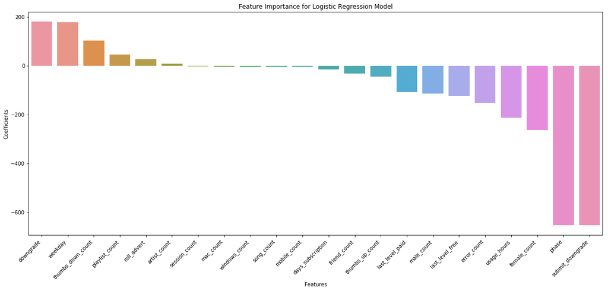

```python
plt.figure(figsize=(20,8))
sns.barplot(x='feature', y='coefficients', data=lt_feature_coefficients_df)
plt.title('Feature Importance for Logistic Regression Model')
plt.xlabel('Features')
plt.ylabel('Coefficients')
plt.xticks(rotation=45, ha='right')
plt.show()
```

# Hyperparameter Tuning

```python
# Logistic Regression
lr = LogisticRegression(featuresCol='scaled_features', labelCol='label')

# Define the hyperparameter grid
lr_param = ParamGridBuilder() \
    .addGrid(lr.regParam, [0.01, 0.1, 1.0]) \
    .addGrid(lr.elasticNetParam, [0.0, 0.5, 1.0]) \
    .addGrid(lr.maxIter, [10, 20, 30]) \
    .build()

lr_model = build_model(lr, lr_param)
lr_tuned_model = train_model("Logistic Regression", lr_model)
```

```
Logistic Regression model fitting took 3242.071615457535 seconds
AvgMetrics: [0.7334201653550751, 0.7432765265682142, 0.7352541137971054, 0.7112790620808065, 0.749135557978238, 0.7446303780459332, 0.7112790620808065, 0.7365386556643869, 0.7470771668839302, 0.7044992150492682, 0.7044992150492682, 0.7044992150492682, 0.6637706587907617, 0.6637706587907617, 0.663770…
```

```python
# Make prediction using a trained Gradient-boosted Tree model
predict_data(lr_tuned_model, "Logistic Regression")
```

```
Logistic Regression Model - Number of Correct Predictions: 26
Logistic Regression Model - Total Number of Predictions: 34
Logistic Regression Model - Accuracy: 0.7647058823529411
Logistic Regression f1: 0.706288032454361
```

# Conclusion

We did a hyperparameter tuning by performing a grid search with different values for the following parameters with the hope of improving accuracy and F1-score.

- regParam(0.01, 0.1, 1.0)
- elasticNetParam (0.0, 0.5, 1.0)
- maxIter (10, 20, 30)

Unfortunately, the accurancy and F1-score reduced to 0.7647 and 0.7062 after lowering maxIter from 100 to 30 as the model may not have enough iterations to converge to the optimal set of coefficients. In addition, the running cost of this tuned model increased significantly with triple training time compared to initial model. Hence, we conclude that we should stick to its default parametes while building Logistic Regression model for this small dataset.

In this analysis, we do not analyze the life cycle of a cohort of Sparkify users. Perhaps getting an understanding of the timing of a churn happens might help us to improve the model performance.

# Final Steps

Clean up your code, adding comments and renaming variables to make the code easier to read and maintain. Refer to the Spark Project Overview page and Data Scientist Capstone Project Rubric to make sure you are including all components of the capstone project and meet all expectations. Remember, this includes thorough documentation in a README file in a Github repository, as well as a web app or blog post.